# 公历十二月

2018年，一月09日

## 一、清醒时间安排情况

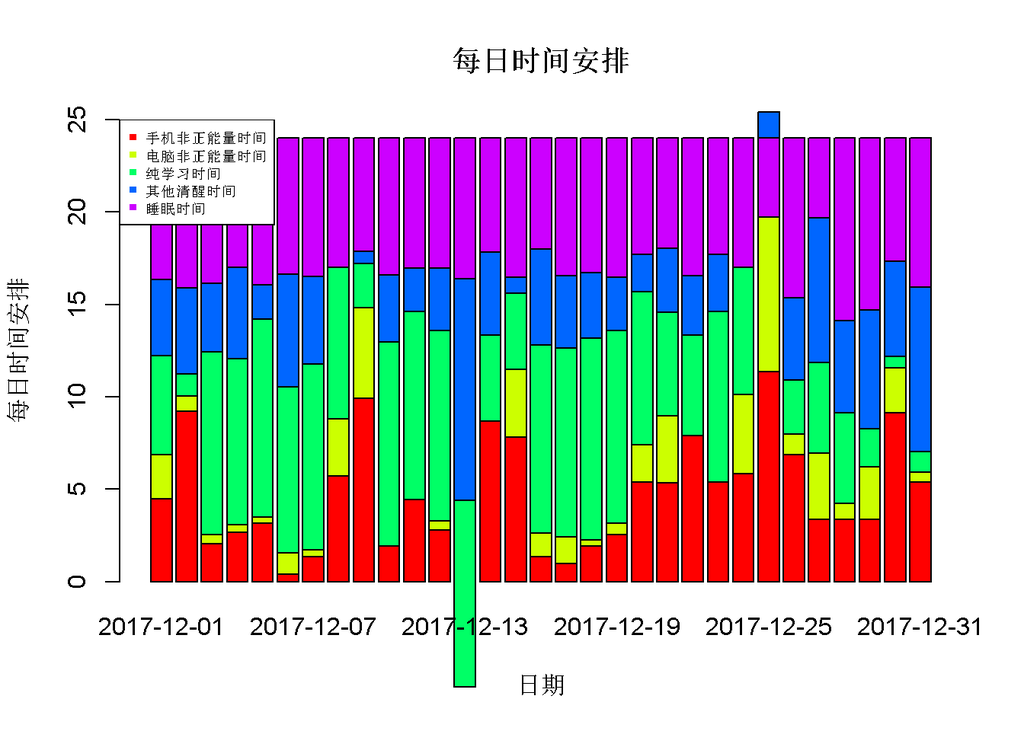

图中反映了本期31天每日时间的构成及其变化，

启动时间，反映了本人自起床开始到做本日第一件事，平均要花1.96小时，占全部清醒时间的11.64%；

纯学习时间，平均为6.8小时，占清醒时间比重为40.35%；

手机非正能量时间每天为4.74小时,占清醒时间比重为28.12%；

电脑非正能量时间平均每天为1.57小时,占清醒时间比重为9.3%。

## 二、睡眠状况

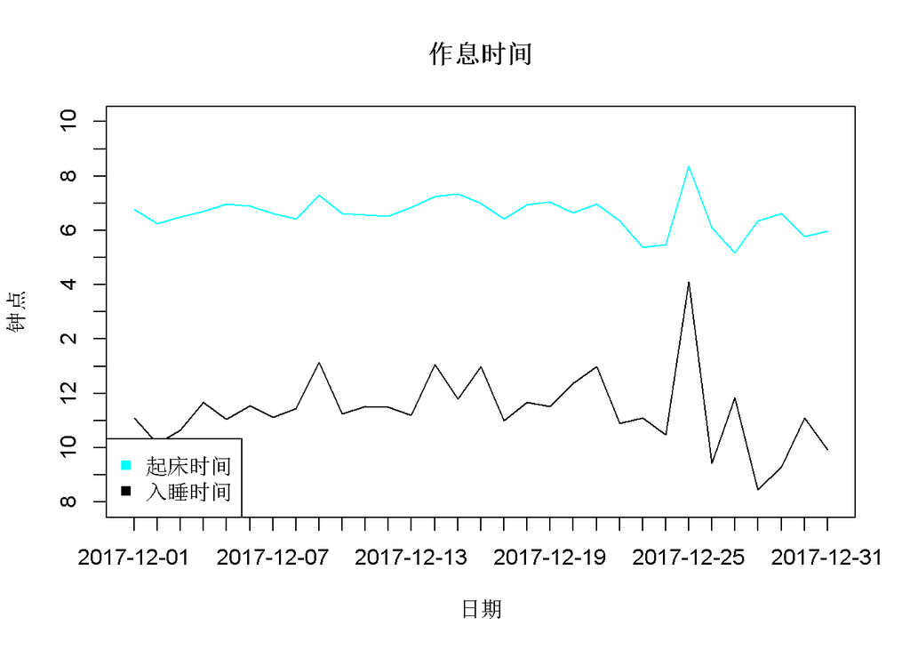

“作息时间”图反映了本期本人每日的入睡与起床时间，在这一期间，本人平均每天11点24分入睡，6点35分起床，睡眠时间平均为7.16小时；

入睡时间和起床时间有显著的相关关系，相较而言，起床时间的波动要比入睡时间更小。

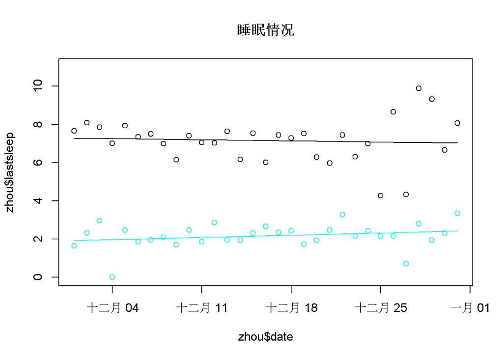

从线性趋势上看，总睡眠时间无明显变化，深睡眠时间无明显变化，睡眠质量向好发展。

## 三、学习状况

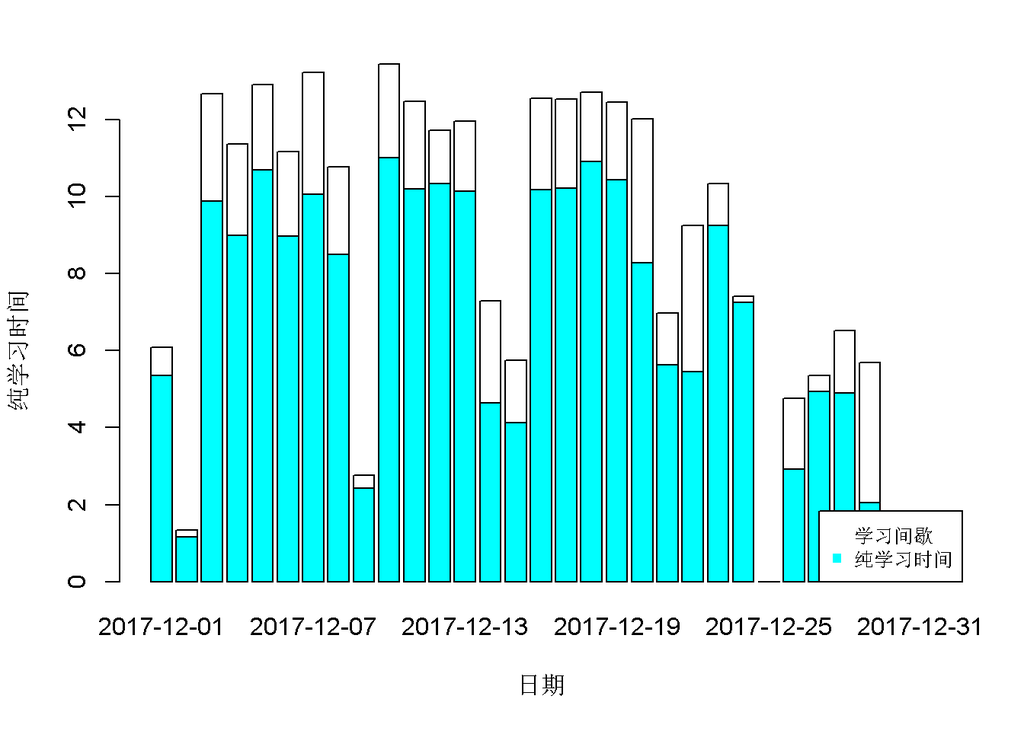

本期平均每日毛学习/工作时间为8.57小时，呈显著减少趋势；

纯学习/工作时间为6.8小时，呈显著减少趋势，用于学习的时间达到了平均水平；

时间利用比为1.26，学习状态良好。

### 核心时间

核心时间指的是完全由自主学习构成，推动复习进度的时间；本期平均每周的核心时间为42.48小时，占纯学习时间的83.61%；

就今年而言，本期核心时间达到了平均水平。

## 四、娱乐时间

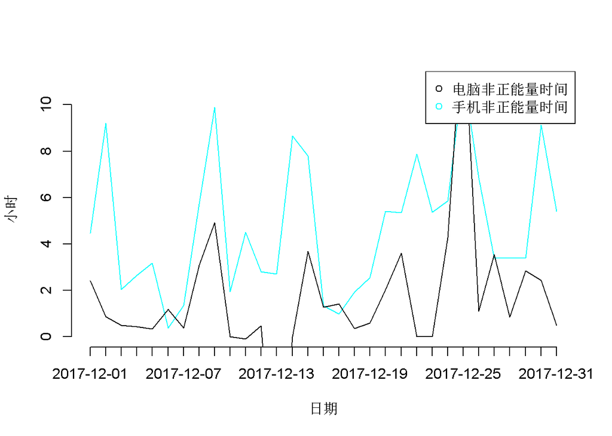

平均每日使用手机时间为5.34小时，本期内无明显变化；其中非正能量时间4.74小时，本期内无明显变化，与纯学习时间 有显著的相关关系。

平均每日使用电脑时间为2.75小时；其中非正能量时间为1.57小时，本期内无明显变化，与纯学习时间 有显著的相关关系。

两者之和 与纯学习时间 有显著的相关关系。